# lab1

# Теперь сравним свойства всех наших векторов. Для начала создадим вектор, содержащий средние значения каждого из 5 полученных ранее распределений в порядке их создания. Полученный вектор сохраним в переменную exp.means. Далее необходимо создать следующие диаграммы рассеяния:

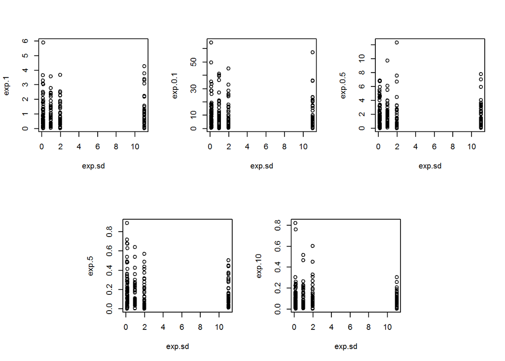

```r
exp.means <- rep(c(M,M1,M2,M3,M4),times=40)
exp.sd <- rep(c(D,D1,D2,D3,D4),times=40)
layout(mat = matrix(c(1,1,2,2,3,3,0,4,4,5,5,0), nrow = 2, byrow = TRUE))
plot(exp.sd,exp.1)
plot(exp.sd,exp.0.1)
plot(exp.sd,exp.0.5)
plot(exp.sd,exp.5)
plot(exp.sd,exp.10)
```

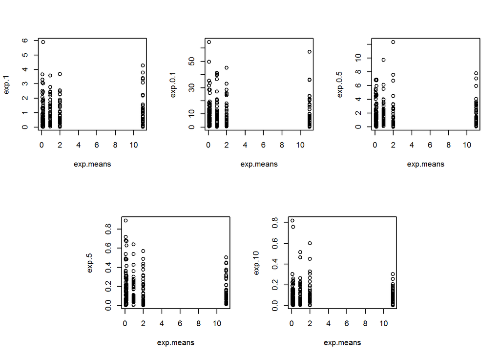

```r
layout(mat = matrix(c(1,1,2,2,3,3,0,4,4,5,5,0), nrow = 2, byrow = TRUE))
plot(exp.means,exp.1)
plot(exp.means,exp.0.1)
plot(exp.means,exp.0.5)
plot(exp.means,exp.5)
plot(exp.means,exp.10)
```

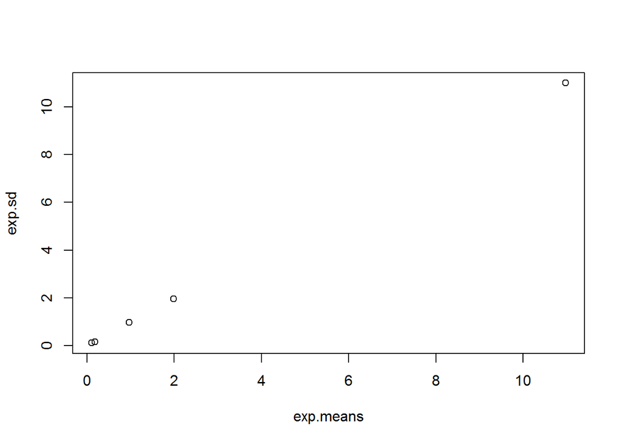

```r
plot(exp.means,exp.sd)
```

##Задание 2 Для демонстрации сгенерируйте 1100000 (1 млн. 100 тысяч) чисел из стандартного экспоненциального распределения и сохраните их в вектор huge.exp.1. Получите среднее и стандартное отклонение.

```r
huge.exp.1<-rexp(n=1100000, rate=1)
mean(huge.exp.1)
```

```
## [1] 0.9997741
```

```r
sd(huge.exp.1)
```

```
## [1] 1.000682
```

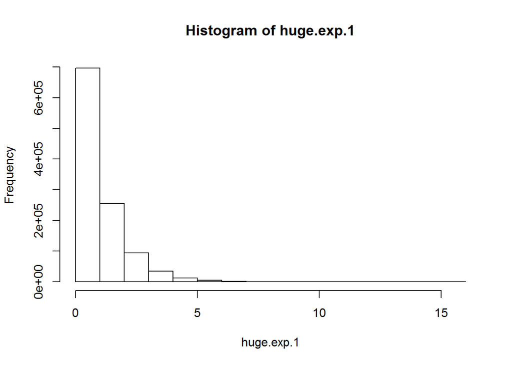

```r
hist(huge.exp.1) #нет
```

```r
mean(huge.exp.1>1)
```

```
## [1] 0.3671364
```

# Получите матрицу huge.exp.1.mat, содержащую 1100 строк и 1000 колонок. Постройте гистограмму, использовав полученную матрицу. Что можно сказать о полученных данных?

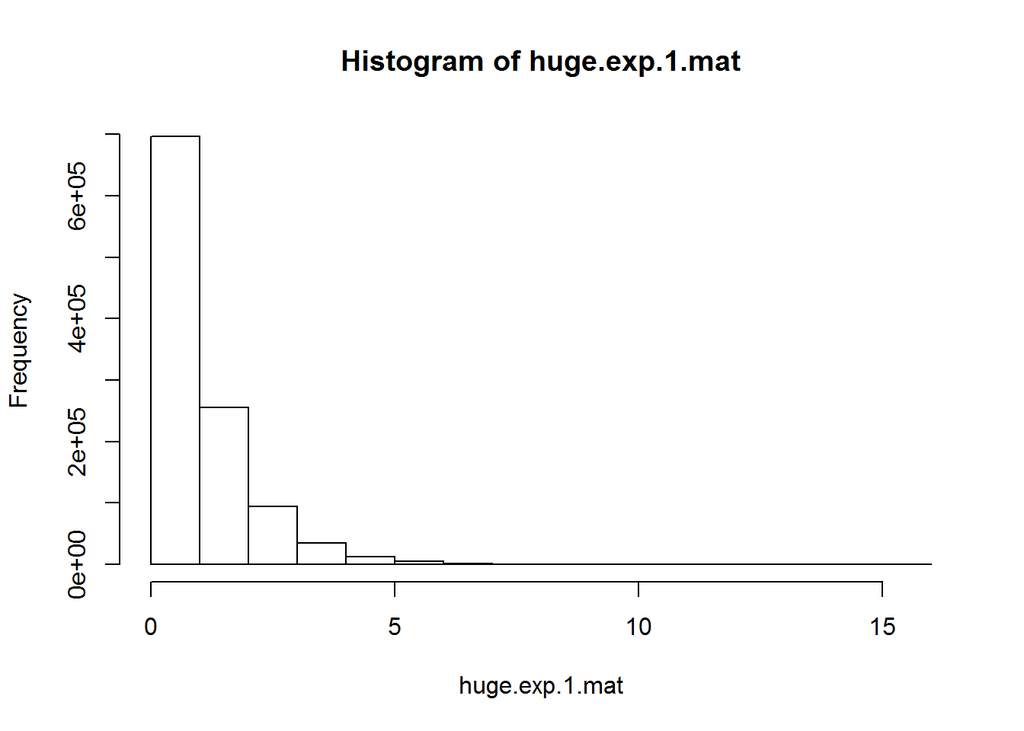

```r
huge.exp.1.mat<-matrix(huge.exp.1,nrow=1100,ncol=1000)
hist(huge.exp.1.mat)
```

# Рассчитайте среднее 137-й колонки из huge.exp.1.mat.

```r
mean(huge.exp.1.mat[,137])
```

```
## [1] 1.010597
```

# Найдите среднее всей 1000 колонок и сохраните их в вектор. Отобразите диаграмму средних зннчений колонок. Объясните почему форма диаграммы отличается от виденных ранее.

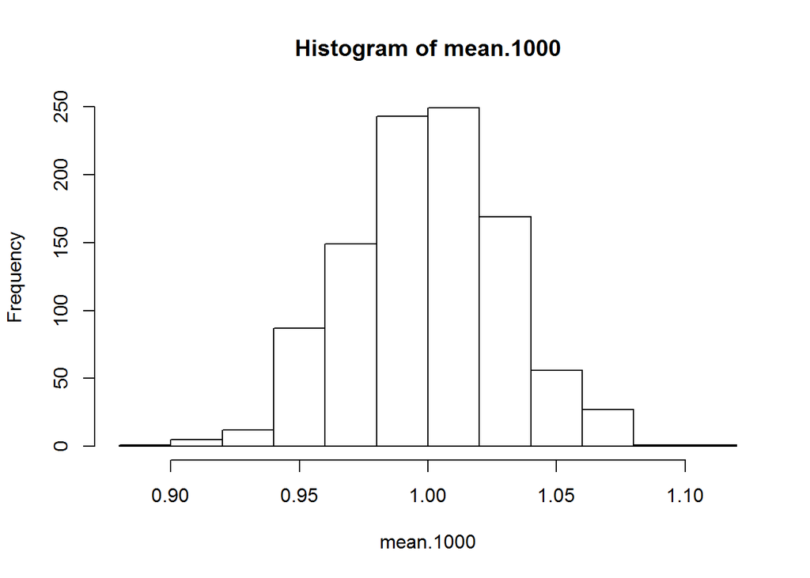

```r
mean.1000 <- colMeans(huge.exp.1.mat)
hist(mean.1000)
```

# Рассчитайте квадрат каждого значения из huge.exp.1 и найдите среднее и стандартное отклонение полученного вектора квадратов. Объясните отличие от соответствующих показателей вектора huge.exp.1. Вам может помочь формула, по которой R рассчитывает стандартное отклонение: sqrt(sum((x - mean(x))^2) / (n - 1)).

```r
huge.exp.1.new  <- huge.exp.1**2
mean(huge.exp.1.new)
```

```
## [1] 2.000911
```

```r
mean(huge.exp.1)
```

```
## [1] 0.9997741
```

```r
sd(huge.exp.1.new)
```

```
## [1] 4.469163
```

```r
sd(huge.exp.1)
```

```
## [1] 1.000682
```

```r
sqrt(sum((huge.exp.1 - mean(huge.exp.1))^2) / (length(huge.exp.1) - 1))
```

```
## [1] 1.000682
```

```r
#все элементы в квадрате -> их показатели отличаются
```